# What is Computer Science?

Introduction to Computation for the Social Sciences

David Garcia

Chapter 1 of “Python Programming: An introduction to Computer Science” by Zelle contains a good introduction to Computer Science. Here we are going to see some basic concepts and broad perspective around computer science.

### What is a Computer?

There are various definitions of what a computer is across disciplines, but a common definition in computer science is:

*“A machine that stores and manipulates information under the control of a changeable program”* (Zelle, 2004)

This definition has important components:

- *A machine*, which means that it is an object that can operate automatically. You can manipulate information with some objects, for example when you manually add numbers in an abacus, but since it is not automated it does not fit the definition of a computer. Sometimes these are called “manual computers” to emphasize that they can store and manipulate information but it requires a human to do so.
- *“Information”*, which is a representation of knowledge or facts. Next session we will learn much more about what we mean by information in Computer Science.
- *“Changeable program”* means that the tasks that a computer can do can be written in a language that defines how information is manipulated. This manipulation of information is what we commonly call “computation” and the program is the defined set of manipulations to do on that information. For example, a traditional calculator is not a computer because, although it can store and manipulate information, it cannot do it based on a program that you can write to define the steps of that manipulation.

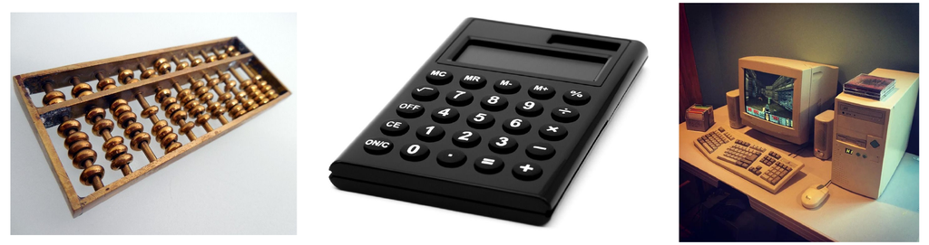

Only one of these three is what we call a modern computer.

### What is computer science?

Computer science studies *computation*, i.e. the the collection, representation, processing, storage and access to information. Despite its name, computer science does not have to be about computers. A common quote about this is:

*“Computer science is no more about computers than astronomy is about telescopes.”* (Attributed to Edsger W. Dijkstra, although not verified)

Beyond computers, computer science also studies the theory of computation and what can be executed by a computer. For example, two common questions in computer science are:

- What can be computed? For example finding what problems can be solved with computation and which have no possible way to be solved with a program.
- How can we solve a problem with computation? For example designing methods and recipes to solve problems, what we call *algorithms*. We will incrementally learn more about algorithms in the next sessions of the course.

### The Sciences of the Artificial

Herbert Simon was a political scientist with great influence in computer science and economics. In the first essays of his book “The Sciences of the Artificial”, he describes a wider scientific context for computer science. Herbert Simon distinguished the sciences of the artificial in contrast to the natural sciences, where the sciences of the artificial study what humans create and not what exists in nature.

These “artificial sciences” are not only descriptive but also prescriptive: they try to find what we should do, not just how things are. As humans we have little power to change nature, but we create the artificial and thus can change it and redesign it. Examples of this prescriptive aspect of the sciences of the artificial can be seen across the social sciences, for example when economists look for a tax incentive to drive innovation or sociologists look for a policy to reduce gender inequality.

Computer science is a prescriptive science since it looks how humans can solve problems with computation. A computer scientist might be looking for a program that:

- calculates how much tax you have to pay based on your documents
- allows a robot to find its way in a maze
- finds the shortest route between two cities
- selects which candidates to interview for a job
- suggests whether to give parole to a prison inmate
- finds where to place refugees in a country

Prescriptive sciences study phenomena with a purpose and two examples are laws and software. In recent years, it has become clearer that computer science has a lot in common with the social sciences. Computer scientists and social scientists are starting to work together to study information technologies with respect to their purpose and broader impact on society. This requires both an understanding of computer science concepts and algorithms and of social science methods and theories. This is especially important when developing new technologies. As Ian Malcolm puts it in Jurassic Park:

*“Your scientists were so preoccupied with whether they could, they didn’t stop to think if they should.”*

The “should” question regarding technology is an example of *computer science as a social science*. Just because a ranking algorithm for job candidates predicts the one chosen in the past, it does not mean that its use would be beneficial for the job market. But to be able to assess that “should” question, you need to understand computation and algorithms (and many other things too, but computing here is essential). This course will give you a set of basis in important aspects of computer science so you can take more advanced courses and dominate the computer science topics that are required to understand the digital society.